# Principal Component Analysis

Author

Miguel Rodo

Published

April 7, 2025

## Context

- Multivariate analysis addresses situations where many variables make analysis difficult.
- **Example:** meteorologists analyze temperature, humidity, wind speed, and other variables to understand weather patterns.
  - Typical questions include:
    - Which variables are correlated?
    - Can we predict rainfall from these variables?
    - What variables clearly distinguish between different weather systems?

### Common issues in multivariate analysis

- **Exploratory data analysis:**
  - With a few variables, pairwise scatterplots are easy.
  - With many variables (e.g., 1000), scatterplots become impractical.
- **Identifying correlated variables:**
  - Correlation heatmaps quickly become cluttered as the number of variables increases.
  - Effective interpretation requires summarization methods or smarter organization.
- **Excess explanatory variables:**
  - Having a large number of explanatory variables may lead to:
    - Models that cannot fit, if there are more explanatory variables than observations.
    - Models that overfit, if there are many explanatory variables relative to the number of observations.
    - Models that take too long to compute.
    - Overly complex interpretation.
- **Correlated explanatory variables:**
  - Highly correlated variables produce unstable parameter estimates.
  - Larger datasets increase the likelihood of encountering highly correlated variables.
- **Multiple dependent variables:**
  - The dependent variables may be correlated, in which case multivariate regression that directly accounts for this can increase accuracy and robustness.

## Types of multivariate analyses

- **Analysing relationships among explanatory variables ($\mathbf{X}\sim\mathbf{X}$):**
  - Methods include PCA, factor analysis, and correspondence analysis (for count data).
  - The aim is to identify groups of correlated variables.
- **Analysing relationships between dependent and explanatory variables ($\mathbf{Y}\sim\mathbf{X}$):**
  - Methods include multivariate regression, canonical correlation analysis, discriminant analysis, and classification.

### Unifying theme

The unifying theme of the techniques discussed is *linearity*:

$$a_1 x_1 + a_2 x_2 + \dots + a_p x_p$$

- Linear combinations of variables form the basis of many multivariate methods. When people refer to “multivariate analysis,” they are often referring to such linear methods.
- Linear techniques were traditionally the only ones available (due to computational constraints), yet they remain widely used because:
  - They are simple to understand and interpret.
  - They are fast to compute.
  - They suffer less from fragility due to excessive flexibility.
- Understanding these foundational approaches is crucial, as they often serve as building blocks for more complex methods. More advanced techniques are frequently discussed in relation to linear methods, making it important to grasp the linear methods first.

## Principal component analysis

- Principal component analysis (PCA) is a linear method for reducing the dimensionality of data.
- The simplest way to think about PCA is that we seek to create a smaller number of new variables that retain as much information as possible about the original variables.

### Choosing the linear combinations

- Consider a random vector $\mathbf{X} \in \mathbb{R}^p$ with zero mean and covariance matrix $\mathbf{\Sigma}$.
- **Goal:** reduce $p$ variables to fewer variables while retaining most information.
- The first principal component ($Y_1$) is a linear combination of the original variables:

$$Y_1 = \mathbf{a}_1'\mathbf{X} = a_{1}^{(1)}X_1 + a_{2}^{(1)}X_2 + \dots + a_{p}^{(1)}X_p$$

- **How to select $\mathbf{a}_1$?**
  - Choose $\mathbf{a}_1$ to maximise the variance of $Y_1$.

## Why maximise variance?

### Minimising variance loses information

- A linear combination with minimal variance is not useful; for example, if a variable has zero variance, all observations are identical, providing no predictive or discriminative information.

### Low variance implies low information

- Variables with minimal variation are less informative:
  - For instance, consider height (1.79–1.81 m) versus weight (50–100 kg): height may provide little practical information compared to weight.

### Statistical benefits of high variance

- Higher variance in predictors improves the precision of regression coefficients.
- Larger variance leads to lower standard errors and more precise estimation.

### Leveraging covariance structure

- The variance of linear combinations is given by:

$$\mathrm{Var}(a_1X_1 + a_2X_2) = a_1^2\,\mathrm{Var}(X_1) + a_2^2\,\mathrm{Var}(X_2) + 2a_1a_2\,\mathrm{Cov}(X_1,X_2)$$

- Positively correlated variables with positive weights increase the combined variance.
- PCA exploits these correlations by assigning larger weights to correlated variables.

### Efficient representation of information

- PCA reduces dimensionality (from $p$ to $r<p$) while minimising information loss.
- Specifically, PCA minimises the reconstruction error (in a least squares sense).

### Joint display of variables and observations

- Standard scatterplots limit visualization to two variables.
- By choosing linear combinations that maximise variation, PCA creates a low-dimensional plot that displays multiple variables simultaneously, aiding interpretation.

## Key advantages of PCA

- Selects informative directions that capture meaningful differences.
- Enhances statistical stability and precision.
- Reflects the underlying correlation structure.
- Enables efficient data compression and visualization.
- Minimises information loss during dimensionality reduction.

### Practical examples of PCA

- **Finance:** reducing correlated stock returns to assist in diversification.
- **Image compression:** representing images with fewer, informative pixels.
- **Genomics:** identifying gene-expression patterns that indicate biological processes.

## Maximising variance mathematically

Suppose $\mathbf{X}$ is a $p$-dimensional random vector with zero mean and covariance matrix $\mathbf{\Sigma}$. We aim to find the linear combination that maximises the variance.

### Objective function for the first principal component

- The objective for choosing the first principal component is:

$$\mathbf{a}_1 = \underset{\mathbf{a}_1}{\arg\max}\; \mathbf{a}_1'\mathbf{\Sigma}\mathbf{a}_1$$

- **Issue:** without constraints, the variance is unbounded.
- **Solution:** restrict $\mathbf{a}_1$ to be a unit vector ($\mathbf{a}_1'\mathbf{a}_1=1$).

### Height and weight example

- Suppose we have a dataset with two correlated variables, such as weight and height.
- The scatterplot of these may look like the following:

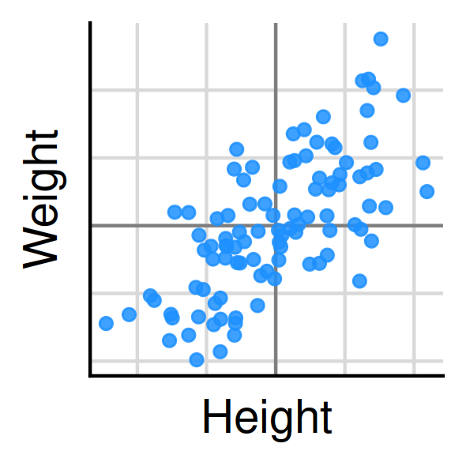

- The first PCA combines these two variables into one: $a_1 \times \text{height} + a_2 \times \text{weight}$.
- For example, suppose we have the point $[1.2, 0.3]$:
  - If we set $\mathbf{a} = [1/\sqrt{2}, 1/\sqrt{2}]$, then the new variable is
    $$\frac{1}{\sqrt{2}} \times 1.2 + \frac{1}{\sqrt{2}} \times 0.3.$$
  - We go from the matrix of variables

```
  height weight
1    1.2    0.3
```

- to

```
     size
1 1.06066
```

- The first principal component can be viewed as representing the “size” of the observation, as both height and weight contribute equally to the new variable, which increases with both.

## Selecting additional principal components

- One component is typically insufficient.

### Objective for the second principal component

- Maximising variance without constraints again would yield the same direction.
- **Solution:** require the second component ($\mathbf{a}_2$) to be orthogonal to the first ($\mathbf{a}_1'\mathbf{a}_2=0$):

$$\mathbf{a}_2 = \underset{\mathbf{a}_2}{\arg\max}\; \mathbf{a}_2'\mathbf{\Sigma}\mathbf{a}_2$$

subject to:

$$\mathbf{a}_2'\mathbf{a}_2=1,\quad \mathbf{a}_2'\mathbf{a}_1=0.$$

#### Height and weight data

- If the first principal component is $[1/\sqrt{2}, 1/\sqrt{2}]$, then the second principal component must be $[1/\sqrt{2}, -1/\sqrt{2}]$.
  - This captures the “shape” of the observation, as taller and thinner individuals have higher values, while shorter and wider individuals have lower values.
- For the example point $[1.2, 0.3]$, the second principal component is calculated as:

  $$\frac{1}{\sqrt{2}} \times 1.2 - \frac{1}{\sqrt{2}} \times 0.3 = 0.64.$$

### General objective for the $k$-th principal component

- Generalising further, the $k$-th component is required to be orthogonal to all previous components.
- The optimization becomes:

$$\mathbf{a}_k = \underset{\mathbf{a}_k}{\arg\max}\; \mathbf{a}_k'\mathbf{\Sigma}\mathbf{a}_k$$

subject to:

$$\mathbf{a}_k'\mathbf{a}_k=1,\quad \mathbf{a}_k'\mathbf{a}_j=0,\; \text{for all } j<k.$$

## How many principal components?

- At most, there can be as many components as original variables ($p$).
- Later components capture progressively less variance.
- Components with zero variance (due to zero eigenvalues) indicate redundancy.
- Typically, one selects a small number of principal components that explain most of the variance.

## Theorem 1: Maximization of quadratic forms for points on the unit sphere

Let $\mathbf{B}$ be a $p \times p$ positive semi-definite matrix with the $i$-th largest eigenvalue $\lambda_i$ and associated eigenvector $\mathbf{e}_i$. Then:

$$\max_{\mathbf{x}\neq \mathbf{0}} \frac{\mathbf{x}'\mathbf{B}\mathbf{x}}{\mathbf{x}'\mathbf{x}} = \lambda_1 \quad (\text{attained when } \mathbf{x}=\mathbf{e}_1)$$

and

$$\max_{\mathbf{x}\neq \mathbf{0},\, \mathbf{x}\perp \mathbf{e}_1, \mathbf{e}_2, \ldots, \mathbf{e}_{i-1}} \frac{\mathbf{x}'\mathbf{B}\mathbf{x}}{\mathbf{x}'\mathbf{x}} = \lambda_i \quad (\text{attained when } \mathbf{x}=\mathbf{e}_{i})$$

for $i\in\{2,3, \ldots, p\}$.

### Proof of theorem 1

Let $\symbf{P}: p \times p$ be the orthogonal matrix whose $i$-th column is the $i$-th eigenvector, and let $\Lambda$ be the diagonal matrix with the eigenvalues arranged in descending order along the diagonal. Define

$$\symbf{B}^{1/2} = \symbf{P}\Lambda^{1/2}\symbf{P}' \quad \text{and} \quad \symbf{y} = \symbf{P}'\symbf{x}.$$

First, we show that the quadratic form can never be larger than $\lambda_1$:

$$\begin{aligned}
\frac{\symbf{x}'\symbf{B}\symbf{x}}{\symbf{x}'\symbf{x}}
&= \frac{\symbf{x}'\symbf{B}^{1/2}\symbf{B}^{1/2}\symbf{x}}{\symbf{x}'\symbf{P}\symbf{P}'\symbf{x}} \\
&= \frac{\symbf{x}'\symbf{P}\Lambda^{1/2}\symbf{P}'\symbf{P}\Lambda^{1/2}\symbf{P}'\symbf{x}}{\symbf{y}'\symbf{y}} \\
&= \frac{\symbf{y}'\Lambda\symbf{y}}{\symbf{y}'\symbf{y}} \\
&= \frac{\sum_{i=1}^p \lambda_i y_i^2}{\sum_{i=1}^p y_i^2} \\
&\leq \lambda_1 \frac{\sum_{i=1}^p y_i^2}{\sum_{i=1}^p y_i^2} \\
&= \lambda_1.
\end{aligned}$$

Now, we show that this upper bound is attained for $\symbf{x} = \symbf{e}_1$. Since eigenvectors are, by convention, unit vectors, we consider

$$\symbf{e}_1'\symbf{B}\symbf{e}_1.$$

First, let $\symbf{c}_i$ be the unit vector with a 1 in the $i$-th position (and 0’s everywhere else).

Expanding $\symbf{B}$ by the eigen-decomposition, we have

$$\symbf{e}_1'\symbf{B}\symbf{e}_1 = \symbf{e}_1'\symbf{P}\Lambda\symbf{P}'\symbf{e}_1.$$

Since $\symbf{B}$ is symmetric, its eigenvectors can be chosen to be orthogonal. This implies that for each $i$, we have

$$\symbf{e}_i'\symbf{P} = \symbf{c}_i',$$

where $\symbf{c}_i$ is the standard basis vector with a 1 in the $i$-th entry. Consequently,

$$\symbf{e}_i'\symbf{P}\Lambda\symbf{P}'\symbf{e}_i = \symbf{c}_i'\Lambda\symbf{c}_i = \lambda_i.$$

In particular, for $i=1$:

$$\symbf{e}_1'\symbf{P}\Lambda\symbf{P}'\symbf{e}_1 = \lambda_1.$$

Now, consider the case where $\symbf{x}$ is orthogonal to $\symbf{e}_1, \symbf{e}_2, \ldots, \symbf{e}_{i-1}$. In this case, each component of the vector $\symbf{y}$ is the dot product of $\symbf{x}$ with an eigenvector $\symbf{e}_i$. Since $\symbf{x}$ is chosen to be orthogonal to the first $i-1$ eigenvectors, the first $i-1$ entries of $\symbf{y}$ are zero.

Returning to the quadratic form, we have

$$\begin{aligned}
\frac{\symbf{x}'\symbf{B}\symbf{x}}{\symbf{x}'\symbf{x}}
&= \frac{\sum_{j=1}^p \lambda_j y_j^2}{\sum_{j=1}^p y_j^2} \\
&= \frac{\sum_{j=i}^p \lambda_j y_j^2}{\sum_{j=i}^p y_j^2} \\
&\leq \lambda_i \frac{\sum_{j=i}^p y_j^2}{\sum_{j=i}^p y_j^2} \\
&= \lambda_i.
\end{aligned}$$

Using the same argument as before, we can show that this maximum value $\lambda_i$ is attained when $\symbf{x} = \symbf{e}_i$.

### Connection with principal components

- Theorem 1 applies by setting $\mathbf{B}=\mathbf{\Sigma}$, the covariance matrix.
- Since
  $$\frac{\mathbf{x}'\mathbf{\Sigma}\mathbf{x}}{\mathbf{x}'\mathbf{x}} = \left(\frac{\mathbf{x}}{\|\mathbf{x}\|}\right)'\mathbf{\Sigma}\left(\frac{\mathbf{x}}{\|\mathbf{x}\|}\right),$$
  the constraint $\|\mathbf{x}\|=1$ is implicit.
- Thus, by applying Theorem 1 in a probabilistic context, we relate the eigen-decomposition of $\mathbf{\Sigma}$ to the variance of the principal components.

## Theorem 2: Selecting principal components

Let $\mathbf{X}$ be a $p \times 1$ random vector with variance-covariance matrix $\mathbf{\Sigma}$, whose $i$-th largest eigenvalue is $\lambda_i$ with associated eigenvector $\mathbf{e}_i$. Then, the $i$-th principal component is defined as:

$$Y_i = \mathbf{e}_i'\mathbf{X},$$

which implies:

$$\mathrm{Var}(Y_i) = \lambda_i \quad \text{for } i \in \{1,2, \ldots, p\},$$
and
$$\mathrm{Cov}(Y_i, Y_j) = 0 \quad \text{for } i\neq j.$$

### Proof of theorem 2

- From Theorem 1:

  $$\max_{\mathbf{x}} \frac{\mathbf{x}'\mathbf{\Sigma}\mathbf{x}}{\mathbf{x}'\mathbf{x}} = \lambda_1,$$

  achieved by setting $\mathbf{x}=\mathbf{e}_1$. Since $\|\mathbf{e}_1\|=1$, it follows that:

  $$\mathrm{Var}(Y_1) = \mathbf{e}_1'\mathbf{\Sigma}\mathbf{e}_1 = \lambda_1.$$
- A similar argument shows that for $i\ge 2$, the maximum variance $\lambda_i$ is attained when $\mathbf{a}_i=\mathbf{e}_i$ under the constraint of orthogonality with the previous eigenvectors.
  - This constraint can always be satisfied as the eigenvectors of a symmetric matrix can be chosen orthogonal.
- Additionally, $\mathrm{Cov}(Y_i, Y_j) = \mathbf{e}_i'\mathbf{\Sigma}\mathbf{e}_j = 0$ for $i\neq j$.

## A note on terminology

- Principal components (the $Y_i$’s) may also be referred to as “scores.”
- The coefficient vectors $\mathbf{a}_i$ may be referred to as “loadings” (algebraically) or “principal axes”/“principal directions” (geometrically).

## Performing PCA using the eigen decomposition

Consider the following variance-covariance matrix:

The resulting matrix is:

|  | V1 | V2 | V3 | V4 | V5 | V6 | V7 |
| --- | --- | --- | --- | --- | --- | --- | --- |
| V1 | 1.0 | 0.9 | 0.9 | 0.0 | 0.0 | 0.0 | 0.0 |
| V2 | 0.9 | 1.0 | 0.9 | 0.0 | 0.0 | 0.0 | 0.0 |
| V3 | 0.9 | 0.9 | 1.0 | 0.0 | 0.0 | 0.0 | 0.0 |
| V4 | 0.0 | 0.0 | 0.0 | 1.0 | 0.9 | 0.9 | 0.9 |
| V5 | 0.0 | 0.0 | 0.0 | 0.9 | 1.0 | 0.9 | 0.9 |
| V6 | 0.0 | 0.0 | 0.0 | 0.9 | 0.9 | 1.0 | 0.9 |
| V7 | 0.0 | 0.0 | 0.0 | 0.9 | 0.9 | 0.9 | 1.0 |

The eigenvectors are stored in the matrix below. We assign row names corresponding to the variables and column names corresponding to the principal components:

Printing the eigenvector matrix (rounded to 2 significant figures) gives:

```
    PC1  PC2   PC3   PC4      PC5    PC6   PC7
V1  0.0 0.58  0.00  0.49  0.0e+00  0.650  0.00
V2  0.0 0.58  0.00 -0.81  0.0e+00  0.099  0.00
V3  0.0 0.58  0.00  0.32  0.0e+00 -0.750  0.00
V4 -0.5 0.00  0.86  0.00  0.0e+00  0.000  0.12
V5 -0.5 0.00 -0.40  0.00 -7.0e-17  0.000  0.77
V6 -0.5 0.00 -0.23  0.00 -7.1e-01  0.000 -0.44
V7 -0.5 0.00 -0.23  0.00  7.1e-01  0.000 -0.44
```

By the variance formula, these linear combinations have the following variances:

```
PC1 PC2 PC3 PC4 PC5 PC6 PC7
3.7 2.8 0.1 0.1 0.1 0.1 0.1
```

These values match the eigenvalues of the variance-covariance matrix, as expected from theorem 2:

```
PC1 PC2 PC3 PC4 PC5 PC6 PC7
3.7 2.8 0.1 0.1 0.1 0.1 0.1
```

Due to the structure of the correlations, the orthogonality constraint forces only two of the principal components to have meaningful variance.

## PCA as rotation

- PCA can be viewed as a rotation of the original variables into new axes (the principal components).
- The first principal component is the direction of maximum variance, and the second is orthogonal to the first, capturing the next highest variance.
- This rotation simplifies the data structure and highlights the most important features.

### First principal component

- Visualise the first principal component as an axis along the vector $\mathbf{a} = [1/\sqrt{2}, 1/\sqrt{2}]$, with the projection of the point $[1.2, 0.3]$ onto this axis forming the new variable:

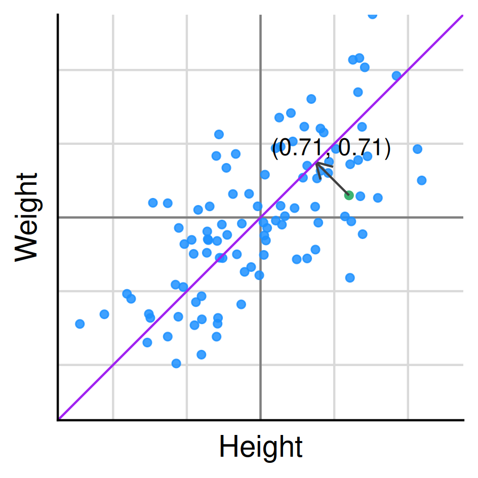

- If we set $\mathbf{a} = [1, 0]$, the new variable is simply the height.
- If we set $\mathbf{a} = [0, 1]$, the new variable is simply the weight.
- This illustrates that the original coordinates can themselves be seen as projections, helping to conceptualise the new axis $[1/\sqrt{2}, 1/\sqrt{2}]$.

### Second principal component

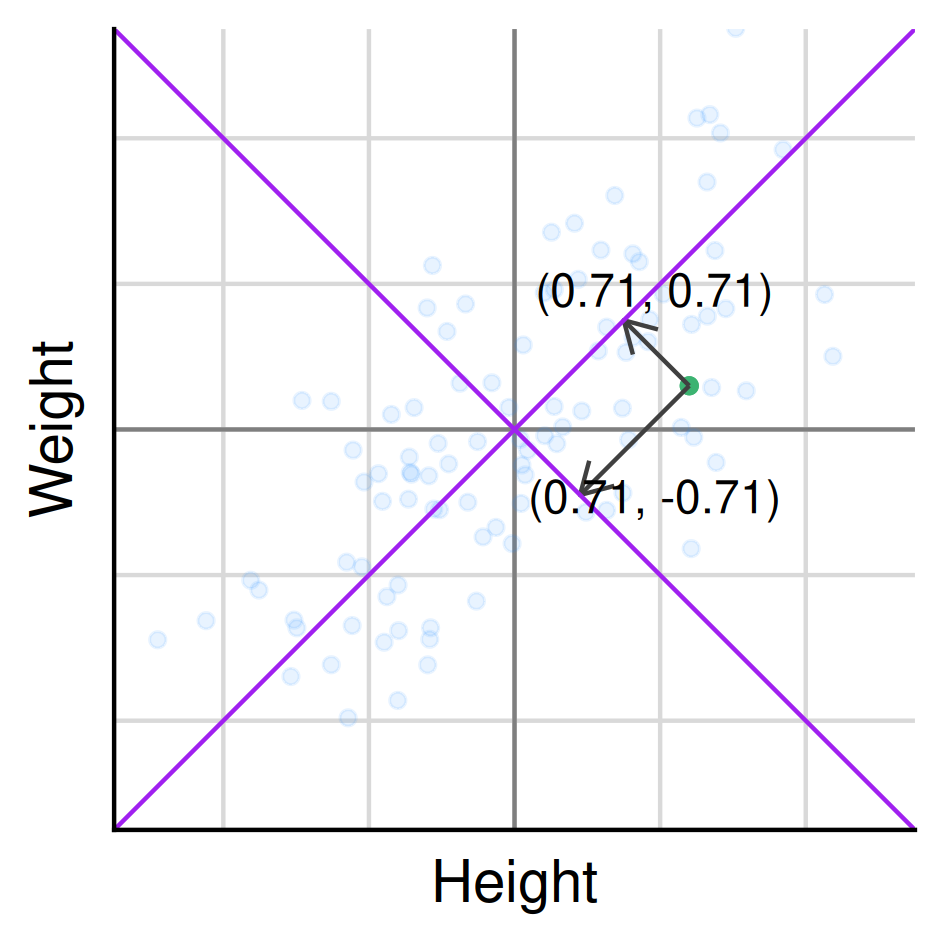

## Theorem three: total variance

Let $\mathbf{X}' = [X_1, X_2, \ldots, X_p]'$ be a random vector with covariance matrix $\mathbf{\Sigma}$ that has eigenvalue–eigenvector pairs $(\lambda_1, \mathbf{e}_1), \ldots, (\lambda_p, \mathbf{e}_p)$, ordered such that $\lambda_1 \ge \lambda_2 \ge \cdots \ge \lambda_p \ge 0$. Define the principal components $Y_i = \mathbf{e}_i'\mathbf{X}$ for $i = 1, \ldots, p$. Then, the sum of the variances of the original variables is equal to the sum of the eigenvalues of $\mathbf{\Sigma}$, which is also equal to the sum of the variances of the principal components:

$$\sum_{i=1}^{p} \sigma_{ii} = \sum_{i=1}^{p} \text{Var}(X_i) = \sum_{i=1}^{p} \lambda_i = \sum_{i=1}^{p} \text{Var}(Y_i).$$

### Proof of theorem three

The trace of the covariance matrix $\mathbf{\Sigma}$ is the sum of the variances of the original variables. Since $\mathbf{\Sigma}$ can be decomposed as
$$\mathbf{\Sigma} = \mathbf{PDP}',$$
where $\mathbf{D}$ is the diagonal matrix of eigenvalues and $\mathbf{P}$ is the matrix of eigenvectors, we have

$$\text{trace}(\mathbf{\Sigma}) = \text{trace}(\mathbf{PDP}') = \text{trace}(\mathbf{D}) = \sum_{i=1}^{p} \lambda_i = \sum_{i=1}^{p} \text{Var}(Y_i).$$

### Contribution per component

$$\text{trace}(\mathbf{\Sigma}) = \sum \lambda_i = \sum \text{Var}(Y_i).$$

This implies that the proportion of the total variance due to the $k^{\text{th}}$ principal component is

$$\frac{\lambda_k}{\sum \lambda_i},\quad k=1,\ldots,p,$$

and, because the principal components are uncorrelated, the proportion of variance accounted for by the first $r$ principal components is given by

$$\frac{\sum_{i=1}^r \lambda_i}{\sum \lambda_i}.$$

#### The scree plot

The scree plot is a graphical representation of the proportion of variance accounted for by each principal component. In this plot, the point $(i, \lambda_i/\sum_{j=1}^{p} \lambda_j)$ is plotted for $i = 1, \ldots, p$. Typically, one looks for the “elbow” in the plot, which indicates the number of principal components to retain. Beyond this point, each additional principal component captures little additional variation.

The generated scree plot is then included as follows:

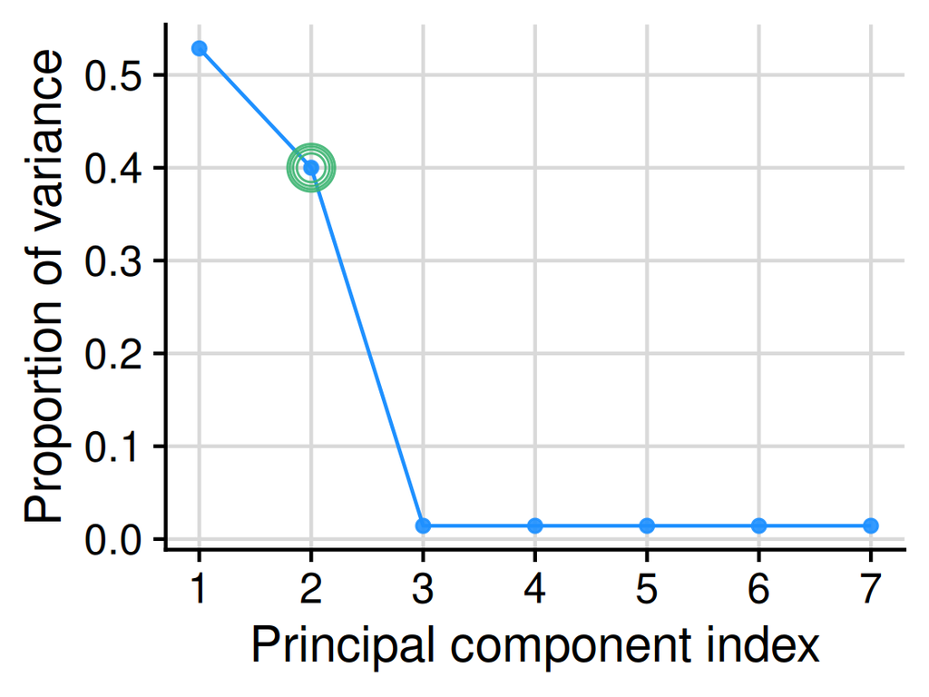

This plot provides a visual guide to selecting the number of principal components that capture the majority of the variance, reinforcing the numerical insights obtained from the eigen decomposition.

## Theorem 4: correlation with original variables

For $Y_i$ and $X_k$, the $i$-th principal component and the $k$-th original variable respectively, we have

$$\rho_{Y_i,X_k} = \frac{\sqrt{\lambda_i}\,e_{ik}}{\sqrt{\sigma_{kk}}}.$$

### Proof of theorem 4

Let $\mathbf{a}_k'$ be a vector that is 1 in the $k$-th position and 0 elsewhere, so that $X_k = \mathbf{a}_k'\mathbf{X}$. Then, note that

$$\begin{aligned}
\text{Cov}(X_k, Y_i) &= \text{Cov}(\mathbf{a}_k'\mathbf{X}, \mathbf{e}_i'\mathbf{X}) \\
&= \mathbf{a}_k'\mathbf{\Sigma}\mathbf{e}_i \\
&= \mathbf{a}_k'\mathbf{PDP}'\mathbf{e}_i \\
&= \lambda_i\,\mathbf{a}_k'\mathbf{e}_i \\
&= \lambda_i\,e_{ik}.
\end{aligned}$$

Since $\text{Var}(Y_i) = \lambda_i$ and $\text{Var}(X_k)=\sigma_{kk}$, the correlation is

$$\rho_{Y_i,X_k}=\frac{\text{Cov}(Y_i,X_k)}{\sqrt{\text{Var}(Y_i)}\,\sqrt{\text{Var}(X_k)}}= \frac{\sqrt{\lambda_i}\,e_{ik}}{\sqrt{\sigma_{kk}}}.$$

## Example

|  | PC1 | PC2 | PC3 | PC4 | PC5 | PC6 | PC7 |
| --- | --- | --- | --- | --- | --- | --- | --- |
| V1 | 0.00 | 0.97 | 0.000 | 0.16 | 0.00 | 0.210 | 0.000 |
| V2 | 0.00 | 0.97 | 0.000 | -0.26 | 0.00 | 0.031 | 0.000 |
| V3 | 0.00 | 0.97 | 0.000 | 0.10 | 0.00 | -0.240 | 0.000 |
| V4 | -0.96 | 0.00 | 0.270 | 0.00 | 0.00 | 0.000 | 0.038 |
| V5 | -0.96 | 0.00 | -0.130 | 0.00 | 0.00 | 0.000 | 0.240 |
| V6 | -0.96 | 0.00 | -0.073 | 0.00 | -0.22 | 0.000 | -0.140 |
| V7 | -0.96 | 0.00 | -0.073 | 0.00 | 0.22 | 0.000 | -0.140 |

In this example, since all variables have unit variance, the only factors that matter in determining the correlation are the eigenvalue and the eigenvector. A high loading (i.e., a large value of $e_{ik}$) combined with a high eigenvalue will lead to a high correlation. Hypothetically, if the variance were higher, it would tend to decorrelate the principal components and the original variables.

## Variance standardisation

Before applying PCA, one can standardise the variances to have unit variance. This may be appropriate when:  
- the variables have different units (e.g. weight in kg vs annual income in rands);  
- the variables have different scales (e.g. some genes are expressed in low quantities if expressed whereas others are expressed in high quantities if expressed); or  
- we wish to eliminate any effect of differences in variance on downstream analyses (for example, when applying penalised regression).

Similar comments apply for logging the data or applying other transformations. All results follow in exactly the same way, with adjustments made in interpreting exactly what variables the principal components capture.

## Standardisation example

Consider the following covariance matrix:

```
     [,1] [,2]
[1,]    1    4
[2,]    4  100
```

This matrix produces the following eigendecomposition:

```
$values
[1] 100.00   0.84

$vectors
     [,1]  [,2]
[1,] 0.04 -1.00
[2,] 1.00  0.04
```

The associated correlation matrix is obtained by first computing the diagonal matrix of standard deviations, inverting it, and then using it to scale the covariance matrix:

```
     [,1] [,2]
[1,]  1.0  0.4
[2,]  0.4  1.0
```

Its eigendecomposition is given by:

```
$values
[1] 1.4 0.6

$vectors
     [,1]  [,2]
[1,] 0.71 -0.71
[2,] 0.71  0.71
```

Notice that the eigenvectors point in very different directions when the variances are standardised.

## Sample principal components

In practice, we do not know $\mathbf{\Sigma}$ and must estimate it using the sample covariance matrix
$$\mathbf{S} = \frac{1}{n}\mathbf{X}'\mathbf{X},$$
assuming that $\mathbf{X}$ is mean‐centred (adjust otherwise). For example, the sample covariance matrix of the height and weight data is:

|  | height | weight |
| --- | --- | --- |
| height | 1.00 | 0.69 |
| weight | 0.69 | 1.00 |

The eigen decomposition of this matrix is then:

```
$values
[1] 1.70 0.31

$vectors
     [,1]  [,2]
[1,] 0.71 -0.71
[2,] 0.71  0.71
```

In this example the first principal component is given by projections onto $[1, 1]$.

If $\mathbf{X} \sim \mathcal{N}(\mathbf{0}, \mathbf{\Sigma})$, then
$$Y_i \sim \mathcal{N}(0, \lambda_i) \quad \text{and} \quad \mathbf{Y} \sim \mathcal{N}_p(\mathbf{0}, \mathbf{\Lambda}).$$
In the height and weight example, we estimate this as
$$\mathbf{Y} \sim \mathcal{N}_p\Big(\mathbf{0}, \begin{bmatrix} 1.71 & 0 \\ 0 & 0.31 \end{bmatrix}\Big).$$

## Approximating a matrix $\mathbf{X}$

Suppose we have a matrix $\mathbf{X}$ of size $n \times p$ with rank $t$ and we wish to approximate it with a matrix $\hat{\mathbf{X}}$ of rank $s < t$. In other words, we wish to find a matrix
$$\hat{\mathbf{X}} = \mathbf{A}\mathbf{B},$$
where $\mathbf{A}$ is of size $n \times s$ and $\mathbf{B}$ is of size $s \times p$, such that
$$\mathbf{X} \approx \hat{\mathbf{X}}.$$
This is the desired rank $s$ approximation to $\mathbf{X}$.

## Approximation example

In the height and weight dataset, we obtained a “size” variable (the first principal component) that is an equally weighted combination of weight and height:
$$\text{size} = \frac{1}{\sqrt{2}}\,\text{height} + \frac{1}{\sqrt{2}}\,\text{weight}
= \begin{pmatrix} \text{height} & \text{weight} \end{pmatrix} \begin{pmatrix} \frac{1}{\sqrt{2}} \\ \frac{1}{\sqrt{2}} \end{pmatrix}.$$
We can approximate the original height and weight variables using the size variable by writing
$$[\text{height}, \text{weight}] \approx \text{size}\,\begin{pmatrix} \frac{1}{\sqrt{2}} & \frac{1}{\sqrt{2}} \end{pmatrix} = \begin{pmatrix} \frac{1}{\sqrt{2}}\,\text{size} & \frac{1}{\sqrt{2}}\,\text{size} \end{pmatrix}.$$
This gives a “rule” for mapping the size variable onto weight and height.

Suppose that for a given observation the height is 0.7 and the weight is 0.5. Then the first principal component (size) is
$$\text{size} = \frac{1}{\sqrt{2}} \times 0.7 + \frac{1}{\sqrt{2}} \times 0.5 = 0.85.$$
We can then approximate the height and weight as follows:
$$\begin{pmatrix} \hat{\text{height}} & \hat{\text{weight}} \end{pmatrix} \approx \begin{pmatrix} \frac{1}{\sqrt{2}} \times 0.85 & \frac{1}{\sqrt{2}} \times 0.85 \end{pmatrix} = \begin{pmatrix} 0.6 & 0.6 \end{pmatrix}.$$
Considering that the standard deviation is (by construction) 1, the error (0.1 in both cases) is small. (If weight and height were very different, the error would be larger.)

## Why do we care about approximation?

Whether or not PCA is a good approximation matters because:

1. We may want to reconstitute the original data after compression (e.g. in image compression).
2. We want to ensure that we are not losing too much information.
3. It provides intuition about what the method is doing.

## Minimising the least squares error of the approximation

We wish to find a matrix $\hat{\mathbf{X}}$ of rank $s$ that minimises the least squares error:
$$\min_{\hat{\mathbf{X}}} \sum_{i=1}^{n} \sum_{j=1}^{p} (x_{ij} - \hat{x}_{ij})^2 = \min_{\hat{\mathbf{X}}} \text{trace}\Big((\mathbf{X} - \hat{\mathbf{X}})(\mathbf{X} - \hat{\mathbf{X}})'\Big).$$
We will: 1. Prove that the singular value decomposition (SVD) can be used to find $\hat{\mathbf{X}}$, and
2. Show that PCA and SVD are equivalent in this context.

## Theorem 5a: SVD approximation

Let $\mathbf{X}$ be a matrix of size $n \times p$ with rank $t$ and SVD
$$\mathbf{X} = \mathbf{U}\mathbf{D}\mathbf{V}',$$
where $\mathbf{D}$ is a diagonal matrix containing the singular values. Then the best rank $s$ approximation to $\mathbf{X}$ is given by
$$\hat{\mathbf{X}} = \mathbf{U}\mathbf{D}\mathbf{J}_s\mathbf{V}',$$
where $\mathbf{J}_s$ is a $p \times p$ diagonal matrix with the first $s$ diagonal elements equal to 1 and the remaining elements equal to 0. Equivalently,
$$\hat{\mathbf{X}} = \sum_{i=1}^{s} d_i\,\mathbf{u}_i\mathbf{v}_i',$$
with $\mathbf{u}_i$ and $\mathbf{v}_i$ denoting the left- and right-singular vectors and $d_i$ the $i$-th singular value of $\mathbf{X}$.

## Proof of Theorem 5a

We begin by using the orthonormality conditions $UU^* = I_m$ and $VV^* = I_k$ to write the sum of squares as
$$\text{tr}[(A - B)(A - B)'] = \text{tr}[UU'(A - B)VV'(A - B)'],$$
(by orthonormality). Using the cyclic property of the trace, this equals
$$\text{tr}[U'(A - B)VV'(A - B)U] = \text{tr}[U'(A - B)V(U'(A - B)V)'].$$
Noting that $\mathrm{tr}(AB) = \mathrm{tr}(B'A')$, we can write
$$\text{tr}[(U'AV-U'BV)(U'AV-U'BV)^*].$$
Since $U'AV = U'UDV'V = D$ and letting $C = U'BV$, we have
$$\text{tr}[(A - B)(A - B)'] = \text{tr}[(D - C)(D - C)'] = \sum_{i,j=1}^{m} (d_{ij} - c_{ij})^2.$$
Because $D$ is diagonal, this sum becomes
$$\sum_{i=1}^{m} (d_i - c_{ii})^2 + \sum_{i\neq j} c_{ij}^2.$$

The quantity
$$\sum_{i=1}^{m} (d_i - c_{ii})^2 + \sum_{i\neq j} c_{ij}^2$$
is minimised when: 1. $c_{ij} = 0$ for $i \neq j$, 2. $c_{ii} = d_i$ for $i \leq s$, and 3. $c_{ii}=0$ otherwise.

We choose the $s$ largest singular values because they reduce the error terms along the diagonals most effectively. Since $\mathbf{U}'\mathbf{B}\mathbf{V}$ is diagonal, the number of nonzero diagonal elements is its rank, which must be $s$ or less. This implies that
$$\mathbf{U}'\mathbf{B}\mathbf{V} = \mathbf{D}\mathbf{J}_s \quad \Rightarrow \quad \mathbf{B} = \mathbf{U}\mathbf{D}\mathbf{J}_s\mathbf{V}'.$$

## Theorem 5b: PCA leads to the same approximation as the SVD

The PCA approximation to $\mathbf{X}$ is given by
$$\tilde{\mathbf{X}} = \mathbf{Y}\mathbf{J}_s\mathbf{P}',$$
where $\mathbf{J}_s$ is the $p \times p$ diagonal matrix with the first $s$ diagonal elements equal to 1 and the rest equal to 0. This is equivalent to the SVD approximation:
$$\hat{\mathbf{X}} = \mathbf{U}\mathbf{D}\mathbf{J}_s\mathbf{V}' = \tilde{\mathbf{X}} = \mathbf{Y}\mathbf{J}_s\mathbf{P}'.$$

## Proof of Theorem 5b

The principal components are given by
$$\mathbf{Y} = \mathbf{X}\mathbf{P}.$$
The first $s$ principal components are
$$\mathbf{Y}\mathbf{J}_s = \mathbf{X}\mathbf{P}\mathbf{J}_s,$$
which effectively sets the last $p-s$ columns of $\mathbf{P}$ to zero. Thus, the approximation to $\mathbf{X}$ is
$$\tilde{\mathbf{X}} = \mathbf{Y}\mathbf{J}_s\mathbf{P}'.$$

Since the columns of $\mathbf{P}$ are the eigenvectors of $\mathbf{X}'\mathbf{X}$ (and hence the right singular vectors of $\mathbf{X}$), we have
$$\mathbf{P} = \mathbf{V}.$$
It follows that
$$\tilde{\mathbf{X}} = \mathbf{Y}\mathbf{J}_s\mathbf{P}' = \mathbf{X}\mathbf{V}\mathbf{J}_s\mathbf{V}' = \mathbf{U}\mathbf{D}\mathbf{J}_s\mathbf{V}' = \hat{\mathbf{X}}.$$

## Example (Painted Turtles data)

We begin by reading in data of measurements on Painted Turtles (Jolicoeur and Mosimann 1960):

Then we load the data:

```
# A tibble: 49 × 4
   gender length width height
   <chr>   <dbl> <dbl>  <dbl>
 1 male       93    74     37
 2 male       94    78     35
 3 male       96    80     35
 4 male      101    84     39
 5 male      102    85     38
 6 male      103    81     37
 7 male      104    83     39
 8 male      106    83     39
 9 male      107    82     38
10 male      112    89     40
# ℹ 39 more rows
```

## Measurements highly correlated

To illustrate that the measurements are highly correlated, we pivot the data into a long format:

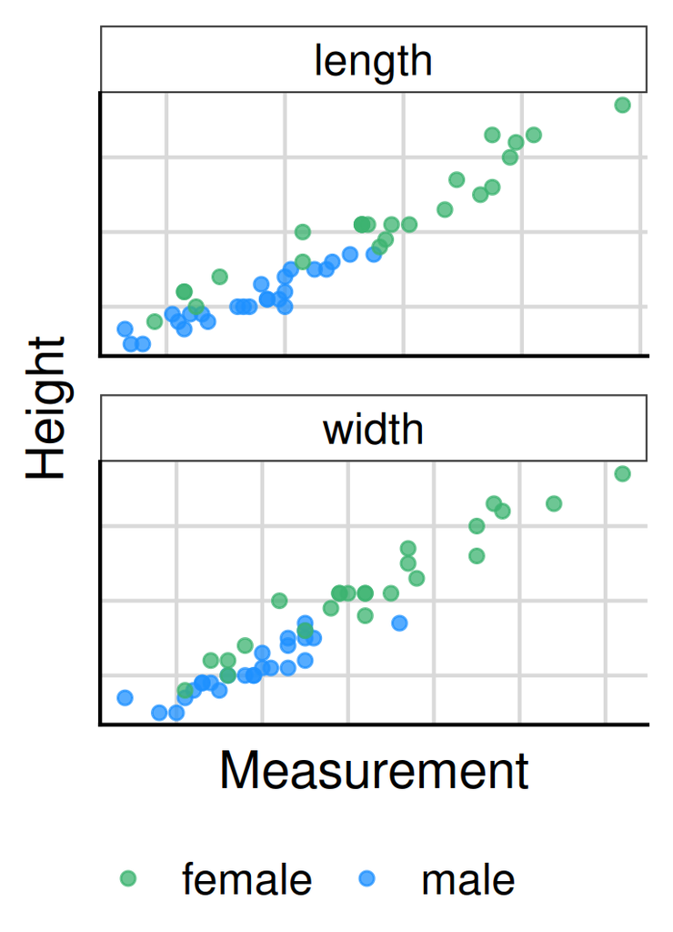

Due to the high correlation, the data can likely be summarised well using principal components. We will use the `prcomp` function in R, and also work from first principles.

## Using the prcomp function I

```
Standard deviations (1, .., p=3):
[1] 0.25969403 0.03573218 0.02104418

Rotation (n x k) = (3 x 3):
                  PC1        PC2         PC3
log(length) 0.6097413 -0.5595404  0.56136451
log(width)  0.4824691 -0.2999000 -0.82297239
log(height) 0.6288395  0.7726413  0.08709957
```

Here, the first principal component has a markedly higher standard deviation and is weighted roughly evenly across the variables, indicating that it is a general “size” variable.

## Using the prcomp function II

```
Importance of components:
                          PC1     PC2     PC3
Standard deviation     0.2597 0.03573 0.02104
Proportion of Variance 0.9751 0.01846 0.00640
Cumulative Proportion  0.9751 0.99360 1.00000
```

The summary provides the per-component standard deviation, variance, and cumulative variance.

## Using the prcomp function III

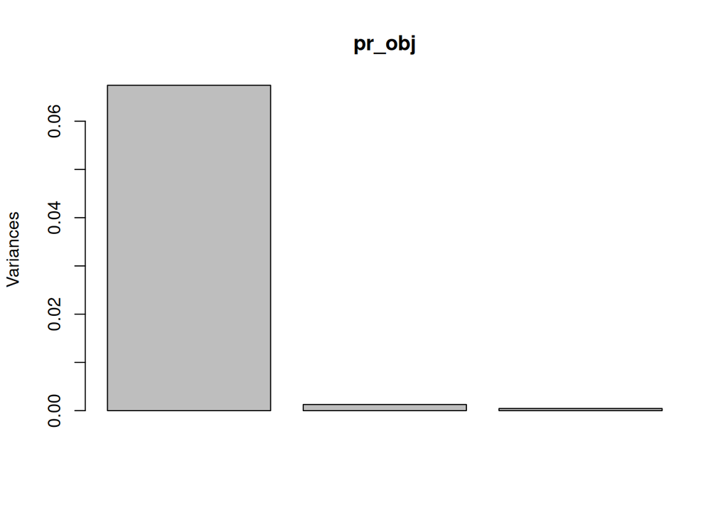

## Using the prcomp function IV

Here are the first few principal components:

```
    PC1     PC2    PC3
1 -0.42  0.0690  0.027
2 -0.42  0.0044 -0.015
3 -0.40 -0.0150 -0.024
4 -0.28  0.0260 -0.026
5 -0.28 -0.0036 -0.032
6 -0.31 -0.0150  0.010
```

Using the SVD, we can obtain the same results as the `prcomp` function. First, remove the gender variable, log-transform and centre the data:

Then, calculate the SVD:

```
[1] 3.2400 0.0613 0.0213
```

The right-singular vectors are the eigenvectors (i.e. the loading vectors), so that the principal components are given by:

```
      [,1]    [,2]   [,3]
[1,] -0.42  0.0690  0.027
[2,] -0.42  0.0044 -0.015
[3,] -0.40 -0.0150 -0.024
[4,] -0.28  0.0260 -0.026
[5,] -0.28 -0.0036 -0.032
[6,] -0.31 -0.0150  0.010
```

## Biplots

Since each data point has many variables, a graphical display of the raw data can be cumbersome. PCA provides an approximate graphical display of the data—a biplot—that shows both each observation and each variable. Typically, the rows (observations) are plotted as points and the columns (variables) as vectors.

### Definition of a biplot

Suppose we have a rank $s$ matrix $\hat{\mathbf{X}} \in \mathbb{R}^{n\times p}$. Then we can write
$$\hat{\mathbf{X}} = \mathbf{A}\mathbf{B},$$
where $\mathbf{A}$ is $n \times s$ and $\mathbf{B}$ is $s \times p$. The biplot is a plot of the rows of $\mathbf{A}$ (the scores, representing the observations) and the columns of $\mathbf{B}$ (the loadings, representing the variables).

### A PCA biplot

The PCA approximation to a matrix $\mathbf{X}$ is given by
$$\mathbf{Y}\mathbf{J}_k\mathbf{P}' = \mathbf{Y}\mathbf{J}_k\mathbf{J}_k\mathbf{P}' = \mathbf{A}\mathbf{B},$$
where $\mathbf{A} = \mathbf{Y}\mathbf{J}_k$ and $\mathbf{B} = \mathbf{J}_k\mathbf{P}'$. Typically, we set $k=2$ and ignore the all-zero columns (or rows) of $\mathbf{A}$ and $\mathbf{B}$.

### Interpreting a biplot

An observation has (approximately) an above‐average value of a variable if it is close to the tip of the vector representing that variable. Two variables are (approximately) correlated if their vectors are close together; they are (approximately) uncorrelated if their vectors are orthogonal.

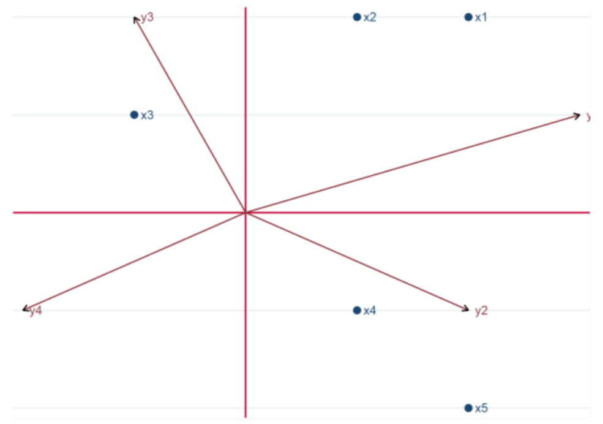

# Resources

- Source code is on [GitHub](https://github.com/MiguelRodo/Slides23RodoHonsMult/blob/2024/SlidesHonsMultL7PCA.qmd).
  - Suppressed code (e.g. to create figures) is available there.

## Supplementary

### Constant‐density contours

The following section, now placed at the end, explains the geometry of the multivariate normal distribution via constant‐density contours.

By the definition of the multivariate normal (MVN) probability density function, the density of $X$ is constant on the ellipsoid defined by the equation
$$(\mathbf{x} - \mu)'\Sigma^{-1}(\mathbf{x} - \mu) = c^2.$$
The ellipsoid’s shape, size and orientation are determined by the eigendecomposition of $\mathbf{\Sigma}$. Without loss of generality, assume that $\mu = \mathbf{0}$. Then, the ellipsoid is defined by
$$c^2 = x'\Sigma^{-1}x = \frac{1}{\lambda_1}(\mathbf{e}_1'\mathbf{x})^2 + \frac{1}{\lambda_2}(\mathbf{e}_2'\mathbf{x})^2 + \ldots + \frac{1}{\lambda_p}(\mathbf{e}_p'\mathbf{x})^2.$$

The axes of the ellipsoid are given by
$$\pm c\sqrt{\lambda_i}\,\mathbf{e}_i, \quad i = 1,2,\ldots,p.$$
Thus, the eigenvectors define the direction of the axes, and the eigenvalues determine their lengths. Furthermore, if we set $y_i = \mathbf{e}_i'\mathbf{x}$ (the $i$-th principal component for $\mathbf{x}$), then
$$c^2 = \frac{1}{\lambda_1}y_1^2 + \ldots + \frac{1}{\lambda_p}y_p^2.$$
That is, the constant-density equation is satisfied by the principal components of $\mathbf{x}$.

## References

Johnson, Richard A., and Dean W. Wichern. 2007. *Applied Multivariate Statistical Analysis*. 6th ed. Upper Saddle River, NJ: Pearson Education Inc.

Jolicoeur, Pierre, and James E. Mosimann. 1960. “Size and Shape Variation in The Painted Turtle: A Principal Component Analysis.” *Growth* 24: 339–54.